# Vote By Mail Analysis

David F. Severski (@dseverski)

Inspired by dinner-table speculation on what point in the 2016 election cycle the actual vote outcome was determined (early voting, absentee votes, states that close ahead of others, etc.), I was interested in looking at rates of absentee voting in the US. My household have been permanent vote-by-mail voters for years and it’s hard for me to envision actually going to a polling location. __[Whacky US Election Laws…*sigh*]–

A quick web searched turned up [this](http://www.nytimes.com/interactive/2012/10/07/us/voting-by-mail.html) graphic from the NYTimes, which referenced the US Election Assistance Commission (EAC) as a data source.

Data available at: https://www.eac.gov/research/election_administration_and_voting_survey.aspx Code book: https://www.eac.gov/assets/1/Page/2014%20EAVS%20Data%20File%20Codebook-2015-06-24-V03-Final.pdf

```r
library(haven)      # for SPSS data file imports
library(tidyverse)  # for data processing assistance
library(viridis)    # for our color scheme
```

The EAC makes data available in several formats. The SPSS dataset looks to be the most ammenable. Below we download the ZIP file, expand it, and read in Section C data (absentee info).

```r
url <- "https://www.eac.gov/assets/1/Page/2014_EAVS_SPSS_Files.zip"
if (!file.exists(file.path("data", "2014_EAVS_SPSS_Files.zip"))) {
  download.file(url, "data/2014_EAVS_SPSS_Files.zip")
}
unzip(file.path("data", "2014_EAVS_SPSS_Files.zip"), exdir = "data", overwrite = TRUE)
dat <- haven::read_sav("data/EAVS_Section_C.sav")
dat
```

| FIPSCode | PreferredOrder | State | Jurisdiction | QC1a | QC1b | QC1c | QC1d | QC1e | QC1f | QC1f_Other | QC1g | QC1g_Other | QC1h | QC1h_Other | QC1_Total | QC1_Comment | QC2 | QC2_Comment | QC3 | QC3_Comment | QC4a | QC4b | QC4c | QC4c_Other | QC4d | QC4_Total | QC4d_Other | QC4_Comment | QC5a | … |
| --- | --- | --- | --- | --- | --- | --- | --- | --- | --- | --- | --- | --- | --- | --- | --- | --- | --- | --- | --- | --- | --- | --- | --- | --- | --- | --- | --- | --- | --- | --- |
| 0100100000 | 2 | AL | AUTAUGA COUNTY | 411 | 318 | NaN | NaN | NaN | NaN |  | NaN |  | NaN |  | 318 | Information contained herein was produced by the Voter Registration & Election Management System as available to the Office of the Alabama Secretary of State. The responsibility for the accuracy of th… |  |  | NaN |  | NaN | NaN | NaN |  | NaN | 0 |  |  | NaN | … |
| 0100300000 | 3 | AL | BALDWIN COUNTY | NaN | NaN | NaN | NaN | NaN | NaN |  | NaN |  | NaN |  | NaN | Information contained herein was produced by the Voter Registration & Election Management System as available to the Office of the Alabama Secretary of State. The responsibility for the accuracy of th… |  |  | NaN |  | NaN | NaN | NaN |  | NaN | NaN |  |  | NaN | … |
| 0100500000 | 4 | AL | BARBOUR COUNTY | NaN | NaN | NaN | NaN | NaN | NaN |  | NaN |  | NaN |  | NaN | Information contained herein was produced by the Voter Registration & Election Management System as available to the Office of the Alabama Secretary of State. The responsibility for the accuracy of th… |  |  | NaN |  | NaN | NaN | NaN |  | NaN | NaN |  |  | NaN | … |
| 0100700000 | 5 | AL | BIBB COUNTY | 94 | 87 | NaN | NaN | NaN | NaN |  | NaN |  | NaN |  | 87 | Information contained herein was produced by the Voter Registration & Election Management System as available to the Office of the Alabama Secretary of State. The responsibility for the accuracy of th… |  |  | NaN |  | NaN | NaN | NaN |  | NaN | 0 |  |  | NaN | … |
| 0100900000 | 6 | AL | BLOUNT COUNTY | 209 | 177 | NaN | NaN | NaN | NaN |  | NaN |  | NaN |  | 177 | Information contained herein was produced by the Voter Registration & Election Management System as available to the Office of the Alabama Secretary of State. The responsibility for the accuracy of th… |  |  | NaN |  | NaN | NaN | NaN |  | NaN | 0 |  |  | NaN | … |
| 0101100000 | 7 | AL | BULLOCK COUNTY | NaN | NaN | NaN | NaN | NaN | NaN |  | NaN |  | NaN |  | NaN | Information contained herein was produced by the Voter Registration & Election Management System as available to the Office of the Alabama Secretary of State. The responsibility for the accuracy of th… |  |  | NaN |  | NaN | NaN | NaN |  | NaN | NaN |  |  | NaN | … |
| 0101300000 | 8 | AL | BUTLER COUNTY | NaN | NaN | NaN | NaN | NaN | NaN |  | NaN |  | NaN |  | NaN | Information contained herein was produced by the Voter Registration & Election Management System as available to the Office of the Alabama Secretary of State. The responsibility for the accuracy of th… |  |  | NaN |  | NaN | NaN | NaN |  | NaN | NaN |  |  | NaN | … |
| 0101500000 | 9 | AL | CALHOUN COUNTY | 513 | 433 | NaN | NaN | NaN | NaN |  | NaN |  | NaN |  | 433 | Information contained herein was produced by the Voter Registration & Election Management System as available to the Office of the Alabama Secretary of State. The responsibility for the accuracy of th… |  |  | NaN |  | NaN | NaN | NaN |  | NaN | 0 |  |  | NaN | … |
| 0101700000 | 10 | AL | CHAMBERS COUNTY | 153 | 148 | NaN | NaN | NaN | NaN |  | NaN |  | NaN |  | 148 | Information contained herein was produced by the Voter Registration & Election Management System as available to the Office of the Alabama Secretary of State. The responsibility for the accuracy of th… |  |  | NaN |  | NaN | NaN | NaN |  | NaN | 0 |  |  | NaN | … |
| 0101900000 | 11 | AL | CHEROKEE COUNTY | 244 | 228 | NaN | NaN | NaN | NaN |  | NaN |  | NaN |  | 228 | Information contained herein was produced by the Voter Registration & Election Management System as available to the Office of the Alabama Secretary of State. The responsibility for the accuracy of th… |  |  | NaN |  | NaN | NaN | NaN |  | NaN | 0 |  |  | NaN | … |

[output cut: 990 more lines]

```r
#class(dat)
dat %>% group_by(State) %>% summarize(total_absentee = sum(QC4_Total, na.rm = TRUE)) %>%
  arrange(desc(total_absentee))
```

| State | total_absentee |
| --- | --- |
| CA | 4583088 |
| WA | 2129759 |
| CO | 1989123 |
| FL | 1869379 |
| OR | 1542047 |
| AZ | 1192537 |
| OH | 716951 |
| IA | 475401 |
| TX | 340300 |
| IL | 273984 |

[output cut: 44 more lines]

```r
table(dat$QC2)
```

```
      N/A   No   NO  Yes
1790    1 1702  320 4389
```

```r
dat %>% group_by(State, QC2) %>% tally
```

| State | QC2 | n |
| --- | --- | --- |
| AK | No | 1 |
| AL |  | 67 |
| AR |  | 9 |
| AR | No | 50 |
| AR | Yes | 16 |
| AS | No | 1 |
| AZ |  | 2 |
| AZ | Yes | 13 |
| CA |  | 58 |
| CO | No | 64 |

[output cut: 62 more lines]

I’m curious on region trends. Combine the EAC data with the built in R datasets on state regions.

```r
state_regions <- data_frame(state.name = state.name, state.abb = state.abb, region = as.character(state.region))
data_with_regions <- left_join(dat, state_regions, by = c("State" = "state.abb"))
data_with_regions %>% group_by(region) %>% tally(QC4_Total)
```

| region | n |
| --- | --- |
| North Central | 2278011 |
| Northeast | 507289 |
| South | 2867720 |
| West | 12281190 |
| NA | 183 |

```r
total_votes <- haven::read_sav("data/EAVS_Section_A.sav")
total_votes_by_state <- group_by(total_votes, FIPSCode, PreferredOrder) %>%
  summarize(registered_voters = sum(QA1a, na.rm = TRUE))
total_votes_by_state
```

| FIPSCode | PreferredOrder | registered_voters |
| --- | --- | --- |
| 0100100000 | 2 | 33806 |
| 0100300000 | 3 | 123477 |
| 0100500000 | 4 | 16227 |
| 0100700000 | 5 | 12072 |
| 0100900000 | 6 | 33891 |
| 0101100000 | 7 | 7236 |
| 0101300000 | 8 | 13225 |
| 0101500000 | 9 | 67065 |
| 0101700000 | 10 | 21743 |
| 0101900000 | 11 | 14822 |

[output cut: 990 more lines]

```r
voters_absentee <- left_join(data_with_regions, total_votes_by_state)
#dat2 <- group_by(voters_absentee, region, State, FIPSCode) %>%
dat2 <- group_by(voters_absentee, State, state.name) %>%
  summarize(percent_absentee = sum(QC4_Total, na.rm = TRUE) / sum(registered_voters) * 100) %>%
  arrange(desc(percent_absentee)) %>%
  filter(percent_absentee != Inf)
dat2
```

| State | state.name | percent_absentee |
| --- | --- | --- |
| OR | Oregon | 70.9064390 |
| CO | Colorado | 54.5098867 |
| WA | Washington | 54.2976480 |
| MT | Montana | 33.2136967 |
| AZ | Arizona | 31.3595611 |
| CA | California | 25.2661620 |
| HI | Hawaii | 22.8944817 |
| IA | Iowa | 22.1883325 |
| FL | Florida | 14.7321859 |
| UT | Utah | 14.1391461 |

[output cut: 43 more lines]

The following graph could be greatly improved – spatial analysis isn’t my forte. Immediate improvements include moving this down to the FIPS code and improving the breaks (it’s not clear that OR has a higher pct than either WA or CO).

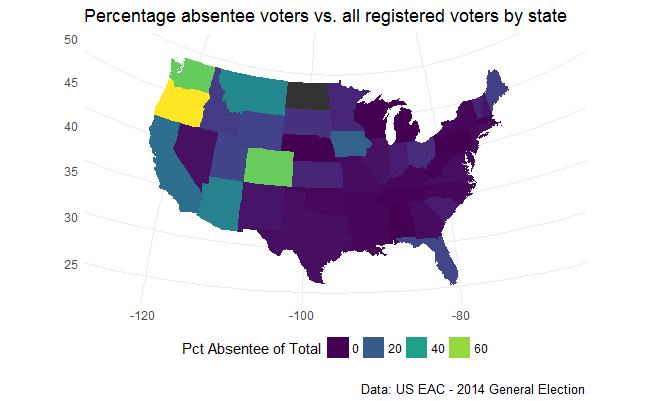

```r
state_map <- map_data("state")
gg <- ggplot()
gg <- gg + geom_map(data = state_map, map = state_map,
                    aes(long, lat, map_id = region))
gg <- gg + geom_map(data = dat2, map = state_map,
                    aes(fill = percent_absentee,
                        map_id = tolower(state.name)))
#gg <- gg + scale_fill_continuous(low='thistle2', high='darkred',  guide='colorbar')
gg <- gg + labs(title = "Percentage absentee voters vs. all registered voters by state",
                caption = "Data: US EAC - 2014 General Election",
                x = NULL, y = NULL,
                fill = "Pct Absentee of Total")
gg <- gg + coord_map("polyconic")
gg <- gg + theme_minimal() + theme(legend.position = "bottom")
#gg <- gg + guide_legend(title = "Percent Absentee of Total")
gg <- gg + scale_fill_viridis(alpha = 0.7, guide = guide_legend(position = "bottom", direction = "horizontal"))
gg
```

There’s a lot of great looking data in the EAC data. More exploration is warranted!